# Kim_Tae-Seung

#### Please delete the Instructions shown above prior to submitting your .Rmd and .html files.

### Test Items starts from here - There are 5 sections - 75 points total

##### Section 1: (15 points)

##### (1) R has probability functions available for use (Kabacoff, Section 5.2.3). Using one distribution to approximate another is not uncommon.

(1)(a) (6 points) The Poisson distribution may be used to approximate the binomial distribution if n > 20 and np < 7. Estimate the following binomial probabilities using *dpois()* or *ppois()* with probability p = 0.05, and n = 100. Then, estimate the same probabilities using *dbinom()* or *pbinom()*. Show the numerical results of your calculations.

1. The probability of exactly 0 successes.

```r
q1_1_np <- .05*100
q1_1_dpois <- dpois(0,q1_1_np)
q1_1_dpois
```

```
## [1] 0.006737947
```

```r
q1_1_dbinom <- dbinom(0,100,0.05)
q1_1_dbinom
```

```
## [1] 0.005920529
```

```r
q1_2_np <- .05*100
q1_2_ppois <- ppois(6, q1_2_np, lower.tail = TRUE)
q1_2_ppois
```

```
## [1] 0.7621835
```

```r
q1_2_pbinom <- pbinom(6, 100, 0.05, lower.tail = TRUE)
q1_2_pbinom
```

```
## [1] 0.766014
```

The binomial may also be approximated via the normal distribution. Estimate the following binomial probabilities using *dnorm()* or *pnorm()*, this time with probability p = 0.25 and n = 100. Then, calculate the same probabilities using *dbinom()* and *pbinom()*. Use continuity correction. Show the numerical results of your calculations.

3. The probability of exactly 25 successes.

```r
q1_3_n <- 100
q1_3_p <- 0.25
q1_3_np <- q1_3_n * q1_3_p
q1_3_sd <- sqrt(q1_3_n * q1_3_p * (1 - q1_3_p))

#dont forget to +.5 and -.5 for pnorm
q1_3_pnorm <- pnorm(25.5, q1_3_np, q1_3_sd) - pnorm(24.5, q1_3_np, q1_3_sd)
q1_3_pnorm
```

```
## [1] 0.09192744
```

```r
q1_3_dbinom <- dbinom(25, q1_3_n, q1_3_p)
q1_3_dbinom
```

```
## [1] 0.09179969
```

4. The probability of fewer than 20 successes. Please note the following, taken from the Normal Distribution R Documentation page, regarding the “lower.tail” argument:

```r
q1_4_n <- 100
q1_4_p <- 0.25
q1_4_np <- q1_4_n * q1_4_p
q1_4_sd <- sqrt(q1_4_n * q1_4_p * (1 - q1_4_p))

#dont forget to -.5 since we're doing less than
q1_4_pnorm <- pnorm(19.5, q1_4_np, q1_4_sd)
q1_4_pnorm
```

```
## [1] 0.1020119
```

```r
#don't forget to -1 since this is inclusive and we want 19 or less
q1_4_pbinom <- pbinom(19, q1_4_n, q1_4_p, lower.tail=TRUE)
q1_4_pbinom
```

```
## [1] 0.09953041
```

(1)(b) (3 points) Generate side-by-side barplots using *par(mfrow = c(1,2))* or *grid.arrange()*. The left barplot will show Poisson probabilties for outcomes ranging from 0 to 10. The right barplot will show binomial probabilities for outcomes ranging from 0 to 10. Use p = 0.05 and n = 100. Title each plot, present in color and assign names to the bar; i.e. x-axis value labels.

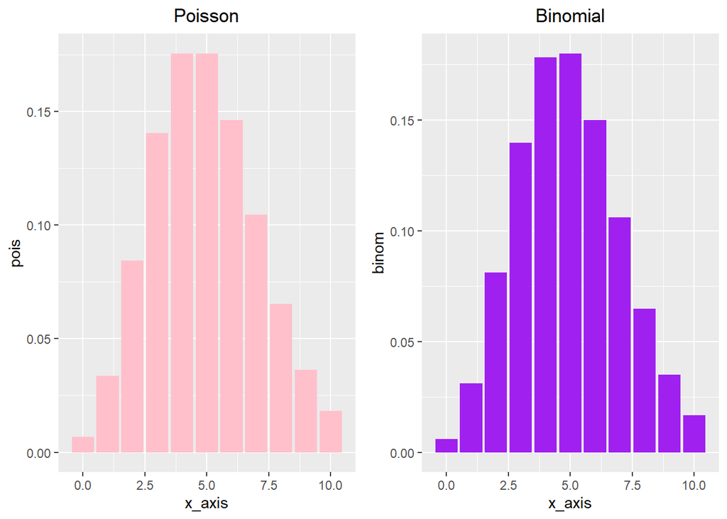

```r
library(ggplot2)
library(gridExtra)

q1b_n <- 100
q1b_p <- 0.05
q1b_np <- 100*0.05


x_axis <- c(seq(0,10))

pois <- dpois(x_axis,q1b_np)

left_df <- data.frame(x_axis,pois)

binom <- dbinom(x_axis, q1b_n, q1b_p)

right_df <- data.frame(x_axis,binom)

left <- ggplot(data=left_df, aes(x = x_axis, y = pois)) +
  geom_bar(stat = 'identity', fill = 'pink') +
  ggtitle('Poisson') +
  theme(plot.title = element_text(hjust = 0.5))

right <- ggplot(data=right_df, aes(x = x_axis, y = binom)) +
  geom_bar(stat = 'identity', fill = 'purple') +
  ggtitle('Binomial') +
  theme(plot.title = element_text(hjust = 0.5))

grid.arrange(left, right, ncol=2)
```

```r
q1c1_x <- c(seq(0,6))

q1c1_y <- c(0.214, 0.230, 0.240, 0.182, 0.130, 0.003, 0.001)

q1c1_df <- data.frame(x = q1c1_x,y = q1c1_y)

q1c1_ev <- round(sum(q1c1_df$x * q1c1_df$y), 1)

q1c1_var <- round(sum(q1c1_df$y * (q1c1_df$x - q1c1_ev)^2), 1)

q1c1_ev
```

```
## [1] 1.8
```

```r
q1c1_var
```

```
## [1] 1.8
```

2. Use the *cumsum()* function and plot the cumulative probabilties versus the corresponding outcomes. Detemine the value of the median for this distribution and show on this plot. Note that there are methods for interpolating a median. However, we can identify an appropriate median from our set of our outcomes - 0 through 6 - that satisfies the definition. Creating a stair-step plot of the cumulative probability as a function of the outcomes may be helpful in identifying it.

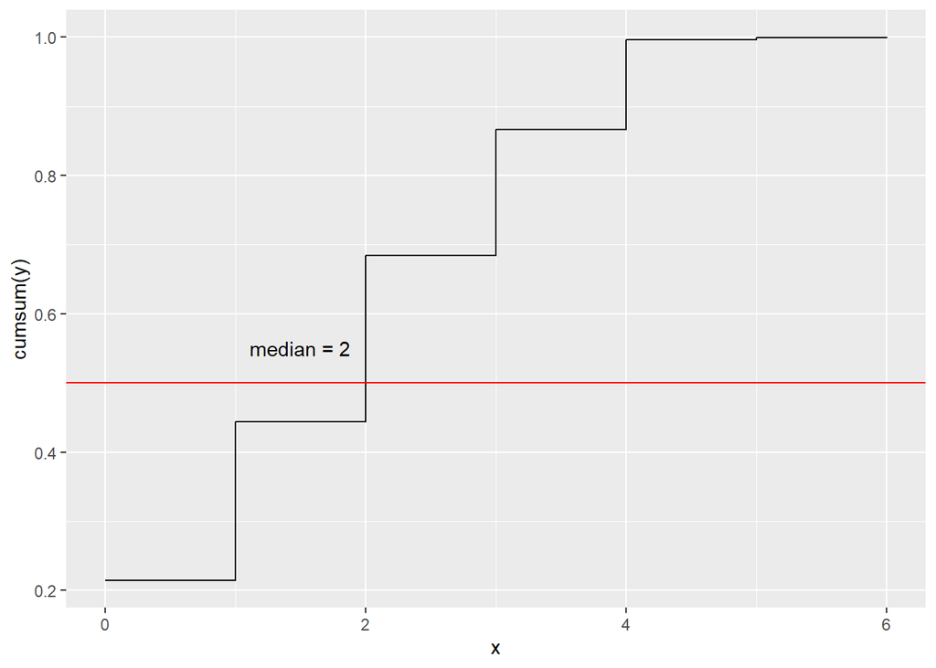

```r
q1c2_plot <- ggplot(data=q1c1_df,aes(x=x,y=cumsum(y))) +
  geom_step() +
  geom_hline(yintercept=0.5,color = 'red') +
  annotate('text',x = 1.5, y= .55, label = 'median = 2')

q1c2_plot
```